# Keeping track of (too many) research projects

**I’ve been unsuccessful in keeping track of all the various ongoing research projects in my lab. A Google Sheet is a good solution, but I found I was just changing entries from “writing” to “submitted” and lost track of where the project had been and where it was going. So I did the unthinkable and applied the tidy-data philosophy to this spreadsheet. Lo and behold, it was suddenly fit for use and automating a report became possible!**

**This also means that I can have a live link to this report for my students so they can see all the ongoing projects and their status as well.**

**I’m documenting my process in case you find it useful.**

**This process makes use of:**

- A named Google Sheet
- RMarkdown (haven’t bothered with Quarto yet because good enough is better than perfect)
- R packages:
  - googledrive
  - googlesheets4
  - tidyverse

**Nothing Earth-shattering here; The key is really just in reorganizing your project data and timelines so that they are “tidy.”**

## Step 1 - Make a Google Sheet with your project info

If you want to use the provided [Rscript](https://raw.githubusercontent.com/gzahn/gzahn.github.io/master/Research_Projects/index.Rmd) and [RMarkdown](https://raw.githubusercontent.com/gzahn/gzahn.github.io/master/Research_Projects/track_projects.R) files (at those links), then you’ll need to name your sheet’s column headers exactly the same as mine. But you’re free to come up with your own schematic if there are fields you want that I don’t include. In any case, my Google Sheet looks like this:

| project | collaborators | lead_author | current_stage | next_step | next_step_target | target_journal | task | task_order | start_date | end_date |
| --- | --- | --- | --- | --- | --- | --- | --- | --- | --- | --- |
| Project A | Jane Doe; John Doe | Jane Doe | Submission | Revisions | 2023-12-31 | Journal A | Writing | 1 | 2023-08-01 | 2023-11-20 |
| Project A | Jane Doe; John Doe | Jane Doe | Submission | Revisions | 2023-12-31 | Journal A | Submission | 2 | 2023-11-21 | 2023-11-30 |
| Project A | Jane Doe; John Doe | Jane Doe | Submission | Revisions | 2023-12-31 | Journal A | Revisions | 3 | 2024-01-15 | 2024-01-31 |
| Project B | Jane Doe; John Doe | Jane Doe | Writing | Submission | 2024-12-31 | Journal B | Writing | 1 | 2024-01-01 | 2024-12-31 |
| Project B | Jane Doe; John Doe | Jane Doe | Writing | Submission | 2024-12-31 | Journal B | Submission | 2 | 2025-01-01 | 2025-02-01 |
| Project C | Jane Doe; John Doe | Jane Doe | Analysis | Writing | 2024-02-01 | Journal C | Data collection | 1 | 2023-06-01 | 2023-09-01 |
| Project C | Jane Doe; John Doe | Jane Doe | Analysis | Writing | 2024-02-01 | Journal C | Analysis | 2 | 2023-09-30 | 2024-01-31 |
| Project C | Jane Doe; John Doe | Jane Doe | Analysis | Writing | 2024-02-01 | Journal C | Writing | 3 | 2023-11-01 | 2024-02-28 |
| Project C | Jane Doe; John Doe | Jane Doe | Analysis | Writing | 2024-02-01 | Journal C | Submission | 4 | 2024-03-01 | 2024-03-31 |
| Project C | Jane Doe; John Doe | Jane Doe | Analysis | Writing | 2024-02-01 | Journal C | Revisions | 5 | 2024-05-01 | 2024-05-30 |

I found it useful to include some **data validation** with my sheet so I don’t spell anything wrong, my dates remain as plain text, *etc.*

Note that each project is repeated as many times as necessary for all the various steps that need to happen.

Step 2 - Link to your Google Sheet in R

For this, the googlesheets4 package is really great. Easy to use and set up with minimal effort. Your sheet can remain private, since it can use the Google API linked to your account. It will take care of this the first time you try to use it.

```r
# LOAD DATA FROM GOOGLE DRIVE ####
dat <- googledrive::drive_get("ResearchProjects") %>%
  googlesheets4::read_sheet() %>%
  mutate(start_date = as.Date(start_date),
         end_date = as.Date(end_date),
         task = factor(task, levels=rev(c("Planning","Securing funding","Data collection","Analysis","Writing",
                                      "Submission","Revisions","Completed"))),
         highlight = case_when(current_stage == task ~ TRUE, TRUE ~ FALSE))
```

## Step 3 - Automate a report

**For this, I use 2 scripts:**

The first, track_projects.R gets in touch with the Google Sheet, builds some basic data frames and figures, and exports them as RDS object files.

The second is a simple RMarkdown, index.Rmd that displays a table of current to-do items and a series of Gantt charts that track the progress of current projects.

The markdown, when knitted, will source the track_projects.R script, incorporating any new changes to the online spreadsheet.

Example of the to-do list output in the report:

| project | current_stage | lead_author |
| --- | --- | --- |
| Project A | Submission | Jane Doe |
| Project B | Writing | Jane Doe |
| Project C | Analysis | Jane Doe |

Example of the Gantt chart output in the report:

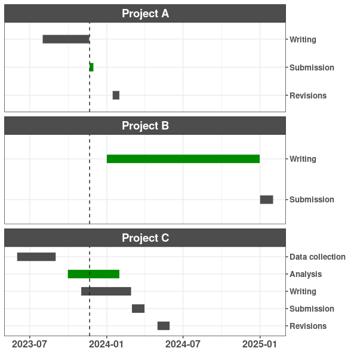

## Step 4 - That’s it. Told you it wasn’t very impressive!